# Week 09: Biking

Alison

2025-03-13

https://christophm.github.io/interpretable-ml-book/bike-data.html

Data from this company: https://www.capitalbikeshare.com/

- instant: record index
- dteday : date
- season : season (1:winter, 2:spring, 3:summer, 4:autumn)
- yr : year (0: 2011, 1:2012)
- mnth : month ( 1 to 12)
- hr : hour (0 to 23)
- holiday : weather day is holiday or not (extracted from [Web Link])
- weekday : day of the week
- workingday : if day is neither weekend nor holiday is 1, otherwise is 0.
- weathersit :
- 1: Clear, Few clouds, Partly cloudy, Partly cloudy
- 2: Mist + Cloudy, Mist + Broken clouds, Mist + Few clouds, Mist
- 3: Light Snow, Light Rain + Thunderstorm + Scattered clouds, Light Rain + Scattered clouds
- 4: Heavy Rain + Ice Pallets + Thunderstorm + Mist, Snow + Fog
- temp : Normalized temperature in Celsius (0-1). The values are derived via (t-t_min)/(t_max-t_min), t_min=-8, t_max=+39 (only in hourly scale)
- atemp: Normalized “feeling” temperature in Celsius (0-1). The values are derived via (t-t_min)/(t_max-t_min), t_min=-16, t_max=+50 (only in hourly scale)
- hum: Normalized humidity. The values are divided to 100 (max)
- windspeed: Normalized wind speed. The values are divided to 67 (max)
- casual: count of casual users
- registered: count of registered users
- cnt: count of total rental bikes including both casual and registered

```r
library(randomForest)
library(tidyverse)
```

Mostly we have done classification. We will use regression, and its evaluation metrics.

https://r-charts.com/colors/ R colour picker!

```r
bike_day <- read_csv('./Bike-Sharing-Dataset/day.csv')
bike_hour <- read_csv('./Bike-Sharing-Dataset/hour.csv')
```

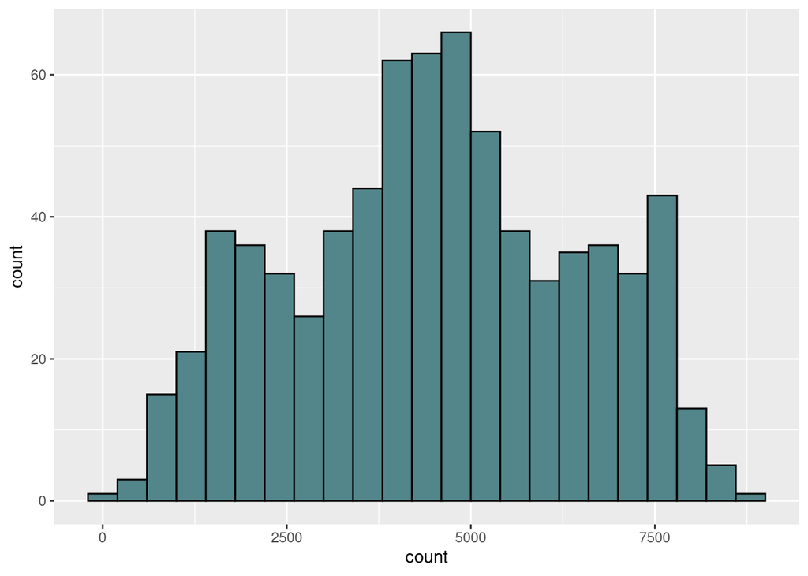

```r
# have to remove registered and casual otherwise we get serious leakage (will just do total counts)
# season needs to be a factor

bike_day <- bike_day %>%
  dplyr::select(-registered, -casual) %>%
  mutate(season = factor(season,
                         levels = c(1,2,3,4),
                         labels = c('Winter', 'Spring', 'Summer', 'Autumn'))) %>%
  mutate(weathersit = factor(weathersit)) %>%                                                 # convert weather situation to factor
  mutate(days = as.numeric(dteday - as.Date("2011-01-01"))) %>%                               # count number of days
  select(count = cnt, season, holiday, yr, days, workingday, weathersit, temp, hum, windspeed)

ggplot(bike_day, aes(x = count)) +
  geom_histogram(binwidth = 400, fill = "cadetblue4", color = "black")                       # plot hist of bike counts/day
```

Create dummy variables from season and weather situation, then create a matrix, and plot

When you see high negative correlations between dummy variables of the same original categorical variable (e.g., weathersit_1 and weathersit_2), it indicates mutual exclusivity. There are some weathersit_3 in there, but not many

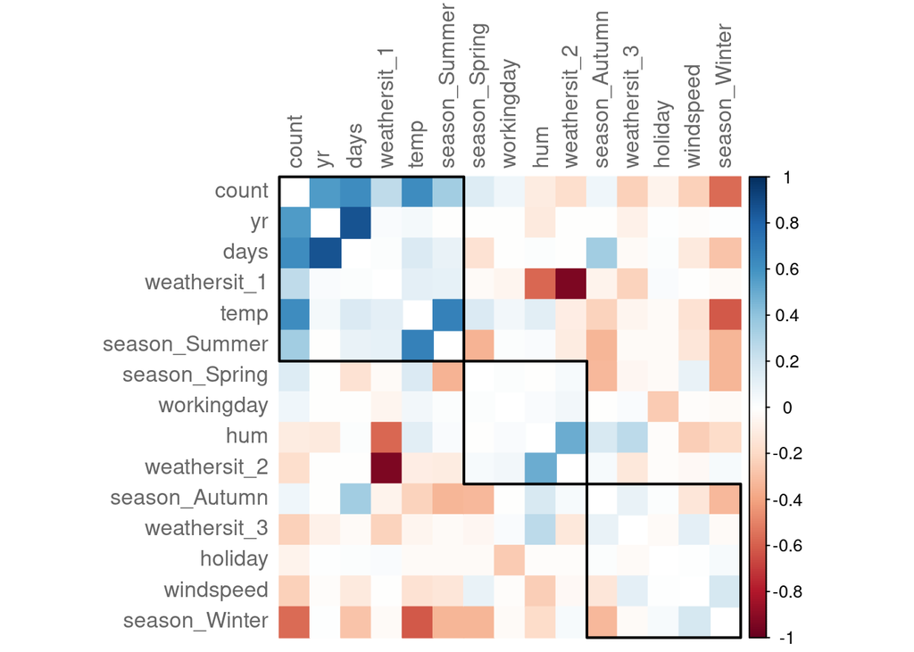

```r
library(corrplot)
library(fastDummies)

mcor <- bike_day %>%
  dummy_cols(select_columns = c('season', 'weathersit')) %>%
  select_if(is.numeric) %>%
  cor
corrplot(mcor, method = 'color', diag = F, tl.col = 'grey40',
         order = 'hclust', addrect = 3)
```

xs_ - data to predict; ys_ - the values we are predicting. Test = 1; train != 1

```r
set.seed(1123)

bike_day$train <- sample(1:10, nrow(bike_day), replace = T)

xs_train <- bike_day %>%
  filter(train != 1) %>%
  select(season:windspeed)
ys_train <- bike_day %>%
  filter(train != 1) %>%
  pull(count)

xs_test <- bike_day %>%
  filter(train == 1) %>%
  select(season:windspeed)
ys_test <- bike_day %>%
  filter(train == 1) %>%
  pull(count)
```

# Linear Regression

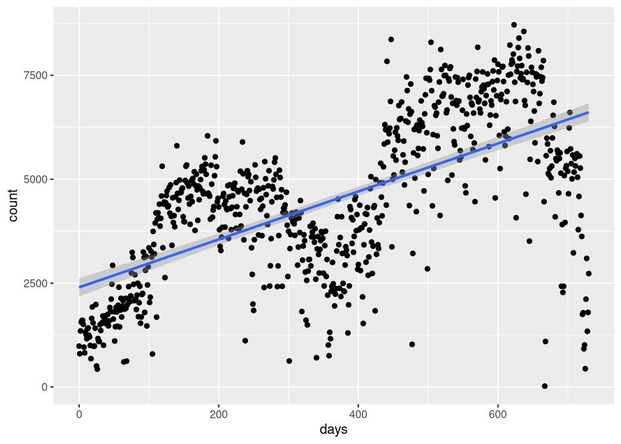

```r
# Simple linear regression

ggplot(bike_day, aes(x=days, y=count)) +
  geom_point() +
  geom_smooth(method="lm")
```

```r
simple_linear_regression <- lm(count ~ days, data=bike_day)
simple_linear_regression   #inspect model
```

```
##
## Call:
## lm(formula = count ~ days, data = bike_day)
##
## Coefficients:
## (Intercept)         days
##    2398.730        5.769
```

```r
# fit model using all the data

bike_lm <- lm(count ~ .,
              data = filter(bike_day, train != 1) %>% select(count:windspeed))
summary(bike_lm)
```

```
##
## Call:
## lm(formula = count ~ ., data = filter(bike_day, train != 1) %>%
##     select(count:windspeed))
##
## Residuals:
##     Min      1Q  Median      3Q     Max
## -3695.7  -402.3    68.4   497.4  3450.1
##
## Coefficients:
##                Estimate Std. Error t value Pr(>|t|)
## (Intercept)   1578.9208   251.4734   6.279 6.36e-10 ***
## seasonSpring  1232.9517   128.5306   9.593  < 2e-16 ***
## seasonSummer   986.3988   184.8416   5.336 1.32e-07 ***
## seasonAutumn  1742.8844   172.1555  10.124  < 2e-16 ***
## holiday       -576.2673   196.8245  -2.928  0.00354 **
## yr            2207.6143   227.7387   9.694  < 2e-16 ***
## days            -0.5475     0.5898  -0.928  0.35365
## workingday     150.2442    75.1043   2.000  0.04588 *
## weathersit2   -424.2398    90.3603  -4.695 3.27e-06 ***
## weathersit3  -1902.4227   218.8778  -8.692  < 2e-16 ***
## temp          5058.8139   337.4811  14.990  < 2e-16 ***
## hum          -1372.4762   331.4684  -4.141 3.94e-05 ***
## windspeed    -2698.0109   468.6402  -5.757 1.34e-08 ***
## ---
## Signif. codes:  0 '***' 0.001 '**' 0.01 '*' 0.05 '.' 0.1 ' ' 1
##
## Residual standard error: 853.3 on 631 degrees of freedom
## Multiple R-squared:  0.8154, Adjusted R-squared:  0.8118
## F-statistic: 232.2 on 12 and 631 DF,  p-value: < 2.2e-16
```

What do the outputs mean?

Adjusted R² = 0.812:

Indicates that approximately 81.2% of the variability in daily bike rentals (count) can be explained by the model predictors, which is very strong performance for a real-world dataset. Residual standard error (853.3):

Typical prediction errors are around +/- 853 bikes per day.

Temperature, weather conditions, and seasonality (especially Autumn) significantly influence bike rentals. Year-on-year growth indicates increased popularity of bikes. Negative effects of humidity, windspeed, and holidays. The slight daily trend (days) is not statistically significant.

Fit to test and train sets Calculate R2 metric - to indicate how well the independent variables explain the variance of the dependent variable. It is expressed as a percentage, with higher percentages indicating a better fit of the model to the data.

Each point compares the actual observed bike counts to the model predictions.

High and similar R2 in training and test sets indicates strong and stable performance. A significant drop in test R2 would signal overfitting.

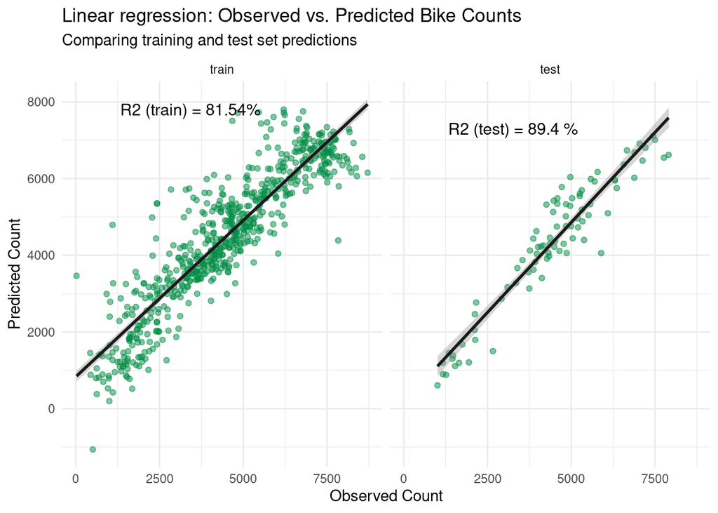

```r
d_train <- tibble(predicted = predict(bike_lm),
                  observed = ys_train,
                  set = 'train')

d_test <- tibble(predicted = predict(bike_lm, newdata = xs_test),
                 observed = ys_test,
                 set = 'test')

d <- bind_rows(d_train, d_test) %>%
  mutate(set = factor(set, levels = c('train', 'test')))

# Calculate R² for training data
ssres_train <- sum((d_train$observed - d_train$predicted)^2)   #discrepancy between predicted and observed data
sstot_train <- sum((d_train$observed - mean(d_train$observed))^2)    #total variance in the observed data
r2_train <- 100 * (1 - ssres_train/sstot_train)

# Calculate R² for test data
ssres_test <- sum((d_test$observed - d_test$predicted)^2)
sstot_test <- sum((d_test$observed - mean(d_test$observed))^2)
r2_test <- 100 * (1 - ssres_test / sstot_test)

# Add R2 annotation coordinates
r2 <- tibble(
  x   = c(quantile(d$observed, 0.05), quantile(d$observed, 0.05)),
  y   = c(max(d$predicted), max(d$predicted) - 500),
  lbl = c(
    paste0("R2 (train) = ", round(r2_train, 2), "%"),
    paste("R2 (test) =", round(r2_test, 2), "%")
  ),
  set = factor(c('train', 'test'), levels = c('train', 'test'))
)

# Plot observed vs predicted
ggplot(d, aes(x = observed, y = predicted)) +
  geom_point(color = 'springgreen4', alpha = 0.5) +
  geom_smooth(method = 'lm', color = 'grey10') +
  geom_text(data = r2, aes(x, y, label = lbl), color = 'black', size = 4, hjust = 0) +
  facet_wrap(~set) +
  labs(x = "Observed Count", y = "Predicted Count",
       title = "Linear regression: Observed vs. Predicted Bike Counts",
       subtitle = "Comparing training and test set predictions") +
  theme_minimal()
```

This is really easy to interpret.

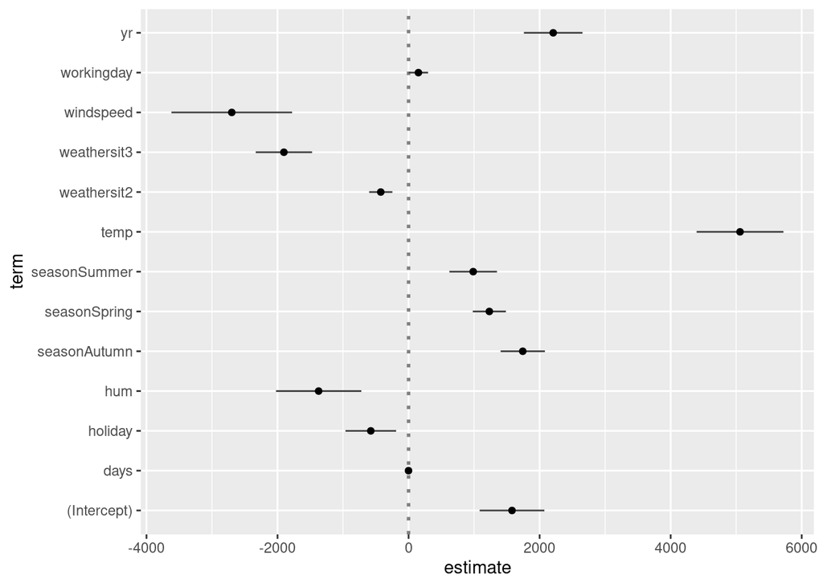

```r
library(GGally)
ggcoef(bike_lm)
```

# Random Forest for regression

Need to make sure `importance = T` and `localImp = T` are both enabled for calculating variable importance

```r
set.seed(5813)
bike_rf <- randomForest(x = xs_train, y = ys_train,
                        xtest = xs_test, ytest = ys_test,
                        importance = T, localImp = T, keep.forest = T)
print(bike_rf)
```

```
##
## Call:
##  randomForest(x = xs_train, y = ys_train, xtest = xs_test, ytest = ys_test,      importance = T, localImp = T, keep.forest = T)
##                Type of random forest: regression
##                      Number of trees: 500
## No. of variables tried at each split: 3
##
##           Mean of squared residuals: 440719.8
##                     % Var explained: 88.59
##                        Test set MSE: 207756.6
##                     % Var explained: 92.87
```

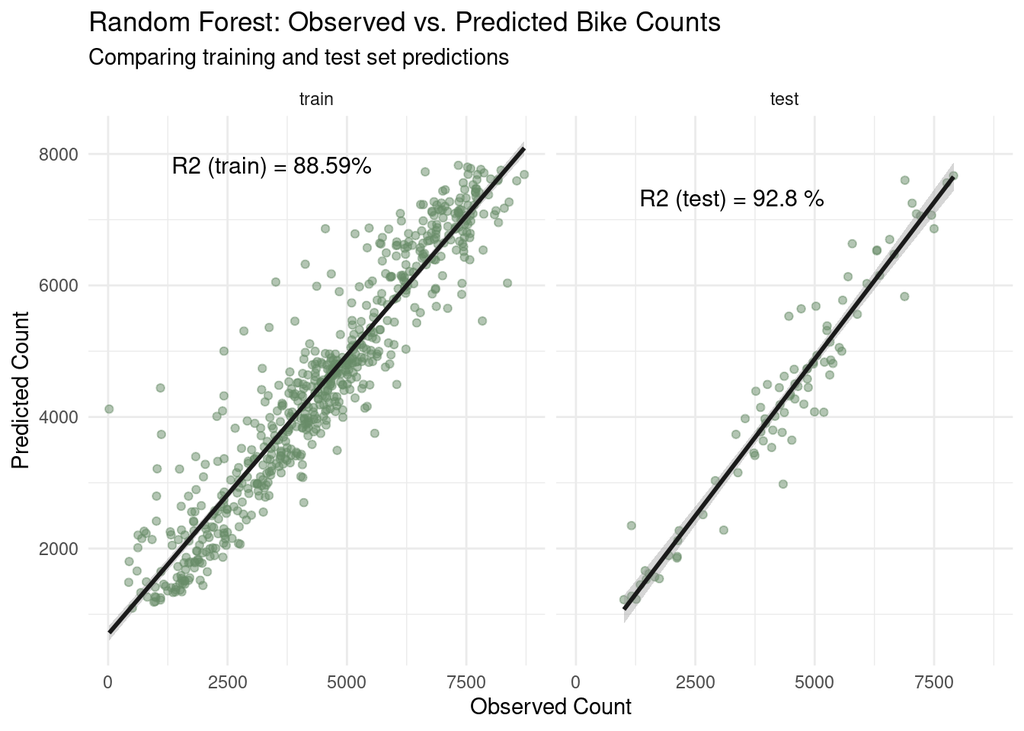

```r
d_train <- tibble(predicted = predict(bike_rf), observed = ys_train, set = 'train')
d_test <- tibble(predicted = predict(bike_rf, newdata = xs_test), observed = ys_test, set = 'test')
d <- bind_rows(d_train, d_test) %>%
  mutate(set = factor(set, levels = c('train', 'test')))

# Calculate R² for training data
ssres_train <- sum((d_train$observed - d_train$predicted)^2)   #discrepancy between predicted and observed data
sstot_train <- sum((d_train$observed - mean(d_train$observed))^2)    #total variance in the observed data
r2_train <- 100 * (1 - ssres_train/sstot_train)

# Calculate R² for test data
ssres_test <- sum((d_test$observed - d_test$predicted)^2)
sstot_test <- sum((d_test$observed - mean(d_test$observed))^2)
r2_test <- 100 * (1 - ssres_test / sstot_test)

# Add R2 annotation coordinates
r2 <- tibble(
  x   = c(quantile(d$observed, 0.05), quantile(d$observed, 0.05)),
  y   = c(max(d$predicted), max(d$predicted) - 500),
  lbl = c(
    paste0("R2 (train) = ", round(r2_train, 2), "%"),
    paste("R2 (test) =", round(r2_test, 2), "%")
  ),
  set = factor(c('train', 'test'), levels = c('train', 'test'))
)

ggplot(d, aes(x = observed, y = predicted)) +
  geom_point(color = 'darkseagreen4', alpha = 0.5) +
  geom_smooth(method = 'lm', color = 'grey10') +
  geom_text(data = r2, aes(x, y, label = lbl), color = 'black', size = 4, hjust = 0) +
  facet_wrap(~set) +
  labs(x = "Observed Count", y = "Predicted Count",
       title = "Random Forest: Observed vs. Predicted Bike Counts",
       subtitle = "Comparing training and test set predictions") +
  theme_minimal()
```

# XGBoost for regression

XGBoost (Extreme Gradient Boosting) is a powerful, tree-based ensemble method that iteratively builds multiple weak predictive models to create a stronger predictive model.

```r
library(xgboost)
set.seed(21)
xgb_train <- xs_train %>%
  dummy_cols(select_columns = c('season', 'weathersit')) %>%
  select_if(is.numeric) %>%
  as.matrix %>%
  xgb.DMatrix(label = ys_train)

xgb_test <- xs_test %>%
  dummy_cols(select_columns = c('season', 'weathersit')) %>%
  select_if(is.numeric) %>%
  as.matrix %>%
  xgb.DMatrix(label = ys_test)

wl <- list(train = xgb_train, eval = xgb_test)

param <- list(max_depth = 2, eta = 0.2, verbose = 0, nthread = 1, gamma = 0,
              subsample = 0.6, min_child_weight = 2,
              objective = "reg:squarederror", eval_metric = "rmse")

bike_xgb <- xgb.train(param, data = xgb_train, watchlist = wl, nrounds = 200)
```

```
## [17:53:06] WARNING: src/learner.cc:767:
## Parameters: { "verbose" } are not used.
##
```

[figure not shown]

```r
d_train <- tibble(predicted = predict(bike_lm),
                  observed = ys_train,
                  set = 'train')

d_test <- tibble(predicted = predict(bike_lm, newdata = xs_test),
                 observed = ys_test,
                 set = 'test')

d <- bind_rows(d_train, d_test) %>%
  mutate(set = factor(set, levels = c('train', 'test')))

# Calculate R² for training data
ssres_train <- sum((d_train$observed - d_train$predicted)^2)   #discrepancy between predicted and observed data
sstot_train <- sum((d_train$observed - mean(d_train$observed))^2)    #total variance in the observed data
r2_train <- 100 * (1 - ssres_train/sstot_train)

# Calculate R² for test data
ssres_test <- sum((d_test$observed - d_test$predicted)^2)
sstot_test <- sum((d_test$observed - mean(d_test$observed))^2)
r2_test <- 100 * (1 - ssres_test / sstot_test)

# Add R2 annotation coordinates
r2 <- tibble(
  x   = c(quantile(d$observed, 0.05), quantile(d$observed, 0.05)),
  y   = c(max(d$predicted), max(d$predicted) - 500),
  lbl = c(
    paste0("R2 (train) = ", round(r2_train, 2), "%"),
    paste("R2 (test) =", round(r2_test, 2), "%")
  ),
  set = factor(c('train', 'test'), levels = c('train', 'test'))
)

# Plot observed vs predicted
ggplot(d, aes(x = observed, y = predicted)) +
  geom_point(color = 'rosybrown', alpha = 0.5) +
  geom_smooth(method = 'lm', color = 'grey10') +
  geom_text(data = r2, aes(x, y, label = lbl), color = 'black', size = 4, hjust = 0) +
  facet_wrap(~set) +
  labs(x = "Observed Count", y = "Predicted Count",
       title = "XGBoost: Observed vs. Predicted Bike Counts",
       subtitle = "Comparing training and test set predictions") +
  theme_minimal()
```

# Explain the results

Two resources on interpretable machine learning (how to understand your models and how they are making their predictions):

http://uc-r.github.io/iml-pkg https://christophm.github.io/interpretable-ml-book/

```r
# The interpretable machine learning package
library(iml)
```

Need to create a function that outputs a value with the model and new data. Doesn’t matter what model you do, the prediction function needs to work this way.

```r
xgb_pred <- function(model, newdata) {
  xs <- newdata %>%
    dummy_cols(select_columns = c('season', 'weathersit')) %>%
    select_if(is.numeric) %>%
    as.matrix %>%
    xgb.DMatrix()
  predict(model, newdata = xs)
}
```

Linear regression is easy to see how predictions are made. xgboost is more opaque

```r
bike_xgb_predictor <- Predictor$new(bike_xgb,
                                    data = xs_train,
                                    y = ys_train,
                                    predict.fun = xgb_pred)
```

# Explain away

## Importance

We can look at feature importance of XGBoost model. Why are days so important here, but insignificant for the linear regression model?

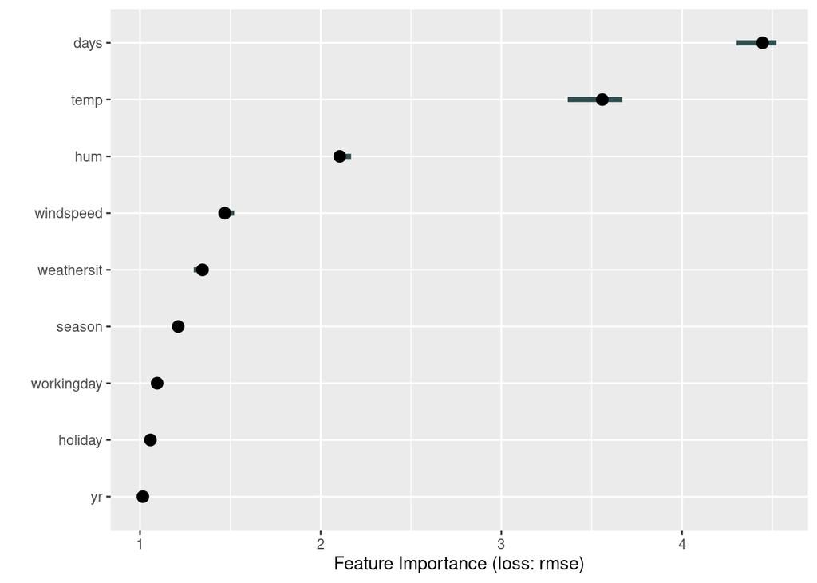

```r
imp <- FeatureImp$new(bike_xgb_predictor, loss = 'rmse')
imp$plot()
```

## Partial dependence - what has the modelled learned about temperature?

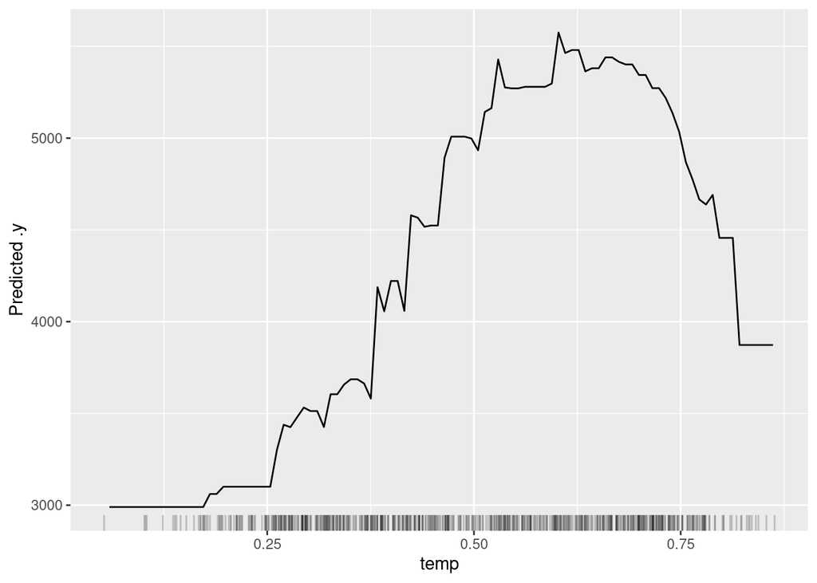

```r
# The influence of varying temperature
eff <- FeatureEffect$new(bike_xgb_predictor, method = 'pdp',
                         feature = 'temp', grid.size = 100)
eff$plot()
```

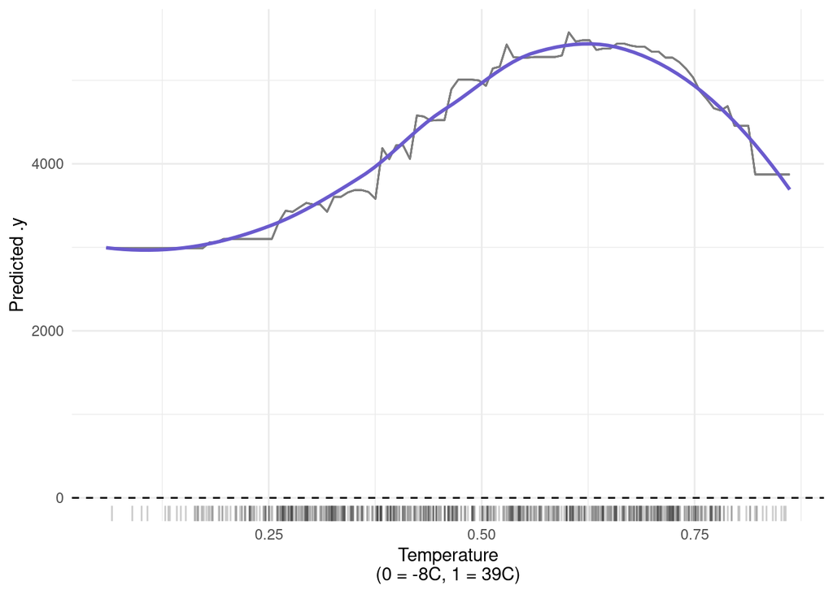

```r
eff$plot() +
  geom_hline(yintercept = 0, linetype = 2) +
  geom_line(color = 'grey50') +
  geom_smooth(method = 'loess', se = F, color = 'slateblue') +
  labs(x = 'Temperature\n(0 = -8C, 1 = 39C)') +
  theme_minimal()
```

# Explain a random day using Shapley values

When applied to machine learning models, it helps in understanding how each feature contributes to the prediction for a specific instance.

A Shapley value for a feature indicates how much that feature pushes the prediction higher or lower relative to the model’s baseline prediction.

Positive SHAP value: Feature increased the prediction. Negative SHAP value: Feature decreased the prediction. Magnitude: Indicates strength of influence on the prediction.

```r
i <- sample(1:nrow(xs_train), 1)

x.interest <- xs_train[i,]
print(x.interest)
```

```
## # A tibble: 1 × 9
##   season holiday    yr  days workingday weathersit  temp   hum windspeed
##   <fct>    <dbl> <dbl> <dbl>      <dbl> <fct>      <dbl> <dbl>     <dbl>
## 1 Summer       0     0   223          1 1          0.708 0.415     0.126
```

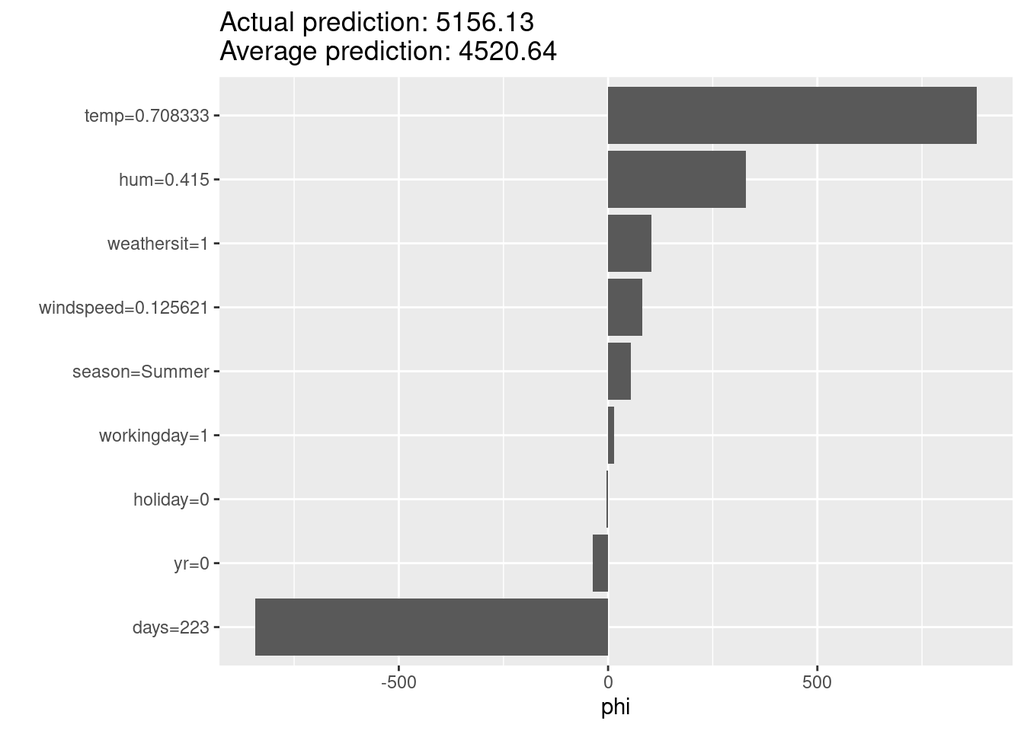

```r
shapley <- Shapley$new(bike_xgb_predictor, x.interest = x.interest)
shapley$plot()
```